# Extensiones del modelo lineal: Regression splines

# 1 Datos

Datos: Wage

Wage and other data for a group of 3000 male workers in the Mid-Atlantic region.

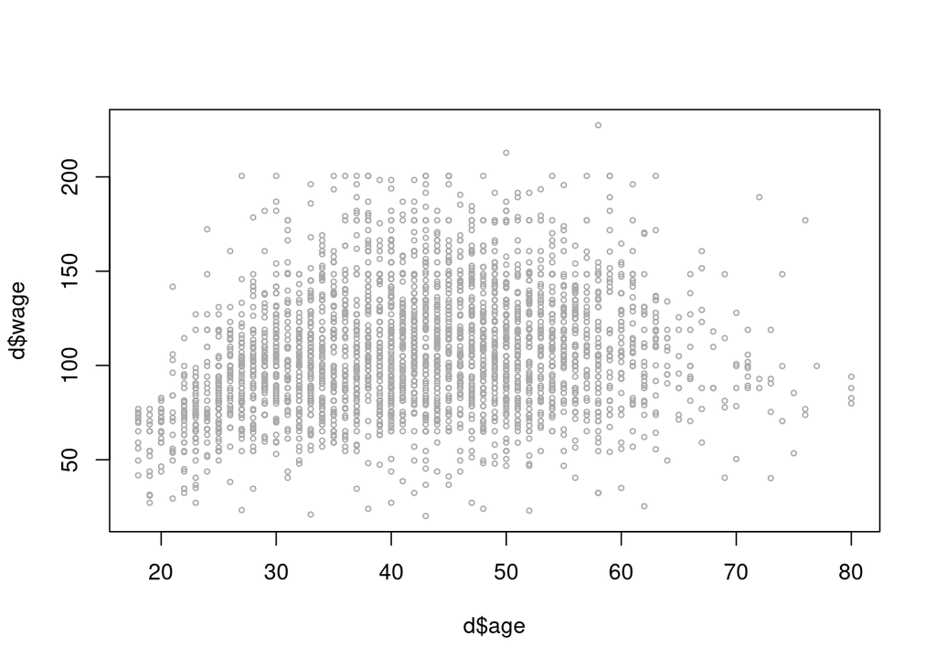

```r
d = read.csv("datos/Wage.csv")
d = d[d$wage<250,]
plot(d$age,d$wage, cex = 0.5, col = "darkgrey")
```

# 2 B-splines o Basis-splines cúbicos

## 2.1 Polinomios cúbicos a trozos

- Se divide el rango de *X* por medio de *k* puntos (o nodos), $c_1 < c_2 < \cdots < c_k$.
- En cada intervalo se estima un polinomio de orden 3.

$$\begin{equation*}
y_i =
\begin{cases}
\beta_{00} + \beta_{10} x_i + \beta_{20} x_i^2 + \beta_{30} x_i^3 + u_i & \text{si } x < c_1,\\
\beta_{01} + \beta_{11} x_i + \beta_{21} x_i^2 + \beta_{31} x_i^3 + u_i & \text{si } c_1 \leq x \leq c_2, \\
\beta_{02} + \beta_{12} x_i + \beta_{22} x_i^2 + \beta_{32} x_i^3 + u_i & \text{si } c_2 \leq x \leq c_3, \\
\ldots & \ldots, \\
\beta_{0k} + \beta_{1k} x_i + \beta_{2k} x_i^2 + \beta_{3k} x_i^3 + u_i & \text{si } x \geq c_k,
\end{cases}
\end{equation*}$$

- Por tanto, hay *(k + 1)(3 + 1)* parámetros a estimar o grados de libertad (son las incógnitas).
- En los puntos $c_1, c_2, \cdots, c_k$ los polinomios han de ser continuos y suaves (segunda derivada continua). Por tanto, se añaden *3* ecuaciones en cada nodo (función continua, primera derivada continua, segunda derivada continua).
- En total se tienen *(k + 1)(3 + 1) - 3k = k + 4* grados de libertad.
- Por tanto, un modelo que utiliza splines de orden 3 y cuatro nodos (k = 4) tiene 8 grados de libertad.
- Si se utilizan polinomios de orden *d* en cada trozo, el numero de grados de libertad sería (k+1)(d+1) - k*d = k + d + 1.

## 2.2 Funciones base

Estimar las ecuaciones anteriores con las restricciones correspondientes no es fácil. Una alternativa es usar *funciones base*.

Es fácil comprobar que el siguiente modelo cumple las condiciones de las splines cúbicas:

$$y_i = \beta_0 + \beta_1 x_i + \beta_2 x_i^2 + \beta_3 x_i^3 + \beta_{4} h_1(x_i) + \cdots + \beta_{3+k} h_{k}(x_i) + u_i$$

donde:

$$\begin{equation*}
h_i(x) =
\begin{cases}
(x - c_i)^3 & \text{si } x > c_i,\\
0 & \text{si } x \leq c_i.
\end{cases}
\end{equation*}$$

y $c_i$ es el punto donde esta el nodo $i$. Por ejemplo, imaginemos un solo nodo en $x_i = a$. A la izquierda de a la spline es:

$$y_{1,i} = \beta_0 + \beta_1 x_i + \beta_2 x_i^2 + \beta_3 x_i^3$$

y a la derecha de a sería:

$$y_{2,i} = \beta_0 + \beta_1 x_i + \beta_2 x_i^2 + \beta_3 x_i^3 + (x_i - a)^3$$

Por tanto en $x_i = a$ se verifica $y_{1,i} = y_{2,i}$, $y_{1,i}' = y_{2,i}'$, $y_{1,i}'' = y_{2,i}''$.

Por otro lado hemos visto que se necesitan *k+4* parámetros en total para una spline cúbica con *k* nodos. Por eso tenemos que llegar hasta $\beta_{k+3}$ (el otro parámetro sería $\beta_0$).

Este polinomio también se puede expresar utilizando una base de tamaño *k+3*:

$$p(x) = a_0 + a_1 b_1(x) + a_2 b_2(x) + \cdots + a_{k+3} b_{k+3}(x)$$

Las $b_k$ son las funciones base.

## 2.3 Funciones base en R

```r
library(splines)
```

La función *bs()* define automaticamente una matriz con las funciones de base necesarias a partir de los nodos. Se puede hacer de dos maneras:

- Especificando los nodos:

```r
dim(bs(d$age, knots = c(25, 40, 60)))
```

```
## [1] 2921    6
```

Tres nodos y splines cúbicos originan una base de tamaño 6 (*k* nodos originan *k+4* parámetros y *k+3* funciones base!):

- Especificando los grados de libertad:

```r
# k = df - 3, se utilizan quantiles para definir los nodos
attr(bs(d$age, df = 6), "knots")
```

```
## 25% 50% 75%
##  33  42  50
```

## 2.4 Estimacion del modelo

```r
nodos = c(25,40,60)
m1 = lm(wage ~ bs(age, knots = nodos), data = d)
summary(m1)
```

```
##
## Call:
## lm(formula = wage ~ bs(age, knots = nodos), data = d)
##
## Residuals:
##     Min      1Q  Median      3Q     Max
## -93.271 -20.467  -2.006  17.424 116.146
##
## Coefficients:
##                         Estimate Std. Error t value Pr(>|t|)
## (Intercept)               59.978      7.151   8.388  < 2e-16 ***
## bs(age, knots = nodos)1    5.534      9.484   0.583 0.559625
## bs(age, knots = nodos)2   44.434      7.280   6.104 1.17e-09 ***
## bs(age, knots = nodos)3   55.949      8.149   6.866 8.04e-12 ***
## bs(age, knots = nodos)4   52.762      8.119   6.498 9.53e-11 ***
## bs(age, knots = nodos)5   40.726     10.942   3.722 0.000201 ***
## bs(age, knots = nodos)6   25.289     14.470   1.748 0.080630 .
## ---
## Signif. codes:  0 '***' 0.001 '**' 0.01 '*' 0.05 '.' 0.1 ' ' 1
##
## Residual standard error: 30.17 on 2914 degrees of freedom
## Multiple R-squared:  0.1096, Adjusted R-squared:  0.1077
## F-statistic: 59.76 on 6 and 2914 DF,  p-value: < 2.2e-16
```

## 2.5 Prediccion

```r
age_grid = seq(from = min(d$age), to = max(d$age), by = 1)
yp = predict(m1, newdata = data.frame(age = age_grid), interval = "confidence", level = 0.95)
yp1 = predict(m1, newdata = data.frame(age = age_grid), interval = "prediction", level = 0.95)
```

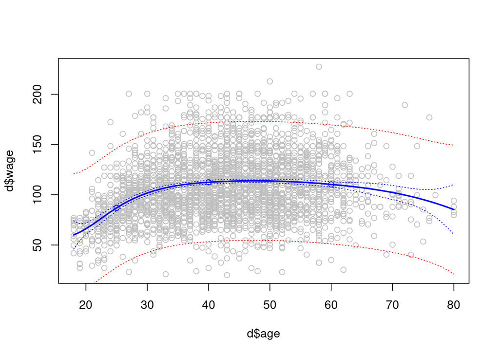

```r
plot(d$age, d$wage, col = "gray")
lines(age_grid, yp[,"fit"], col = "blue", lwd = 2)
lines(age_grid, yp[,"lwr"], col = "blue", lty = 3)
lines(age_grid, yp[,"upr"], col = "blue", lty = 3)
lines(age_grid, yp1[,"lwr"], col = "red", lty = 3)
lines(age_grid, yp1[,"upr"], col = "red", lty = 3)
# incluimos los nodos
nodos_pred = predict(m1, newdata = data.frame(age = nodos))
points(nodos, nodos_pred, col = "blue")
```

# 3 Splines cubicas naturales

## 3.1 Definción

- Las splines tienen el problema de que en los extremos las predicciones tienen varianza elevada.
- Esto se debe a que fuera del rango de la variable (por debajo del minimo y por encima del máximo), la spline sería cúbica.
- Una opción es obligar a que la spline sea lineal en estas zonas. Esto corrige la varianza alta de los bordes.

$$\begin{equation*}
y_i =
\begin{cases}
\beta_{00} + \beta_{10} x_i + u_i & \text{si } x < min(x_i),\\
\beta_{00} + \beta_{10} x_i + \beta_{20} x_i^2 + \cdots + \beta_{d0} x_i^d + u_i & \text{si } min(x_i) \leq x \leq c_1, \\
\beta_{01} + \beta_{11} x_i + \beta_{21} x_i^2 + \cdots + \beta_{d1} x_i^d + u_i & \text{si } c_1 \leq x \leq c_2, \\
\ldots & \ldots, \\
\beta_{0k} + \beta_{1k} x_i + \beta_{2k} x_i^2 + \cdots + \beta_{dk} x_i^d + u_i & \text{si } c_k \leq x \leq max(x_i), \\
\beta_{0k} + \beta_{1k} x_i + u_i & \text{si } x \geq max(x_i),
\end{cases}
\end{equation*}$$

- Para conseguir estas rectas se obliga a que la segunda derivada en los bordes sea cero (si la primera derivada es distinta de cero y la segunda es cero, tenemos una recta).
- Luego se añade 1 restricción en cada extremo, en total hay k + 4 - 2 = k + 2 grados de libertad, k + 1 funciones base.

## 3.2 Splines naturales en R

- En R, se definen splines cúbicas naturales por medio de la función *ns()*.

```r
dim(ns(d$age, knots = c(25, 40, 60)))
```

```
## [1] 2921    4
```

- Se estima el modelo:

```r
nodos = c(25, 40, 60)
m2 = lm(wage ~ ns(age, knots = nodos), data = d)
summary(m2)
```

```
##
## Call:
## lm(formula = wage ~ ns(age, knots = nodos), data = d)
##
## Residuals:
##     Min      1Q  Median      3Q     Max
## -93.310 -20.630  -1.956  17.398 116.207
##
## Coefficients:
##                         Estimate Std. Error t value Pr(>|t|)
## (Intercept)               55.978      3.887  14.400   <2e-16 ***
## ns(age, knots = nodos)1   59.970      3.804  15.765   <2e-16 ***
## ns(age, knots = nodos)2   44.366      4.353  10.193   <2e-16 ***
## ns(age, knots = nodos)3   81.434      9.110   8.939   <2e-16 ***
## ns(age, knots = nodos)4    8.094      7.454   1.086    0.278
## ---
## Signif. codes:  0 '***' 0.001 '**' 0.01 '*' 0.05 '.' 0.1 ' ' 1
##
## Residual standard error: 30.16 on 2916 degrees of freedom
## Multiple R-squared:  0.1094, Adjusted R-squared:  0.1081
## F-statistic: 89.52 on 4 and 2916 DF,  p-value: < 2.2e-16
```

## 3.3 Predicción

```r
ypn = predict(m2, newdata = data.frame(age = age_grid), interval = "confidence", level = 0.95)
ypn1 = predict(m2, newdata = data.frame(age = age_grid), interval = "prediction", level = 0.95)
```

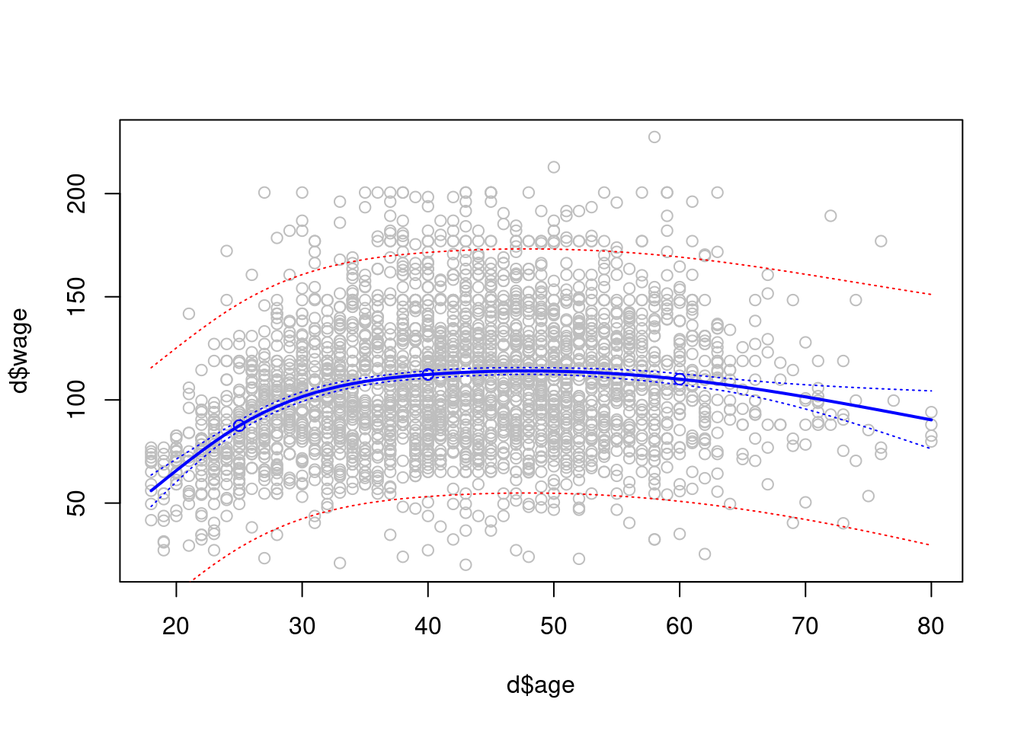

```r
plot(d$age, d$wage, col = "gray")
lines(age_grid, ypn[,"fit"], col = "blue", lwd = 2)
lines(age_grid, ypn[,"lwr"], col = "blue", lty = 3)
lines(age_grid, ypn[,"upr"], col = "blue", lty = 3)
lines(age_grid, ypn1[,"lwr"], col = "red", lty = 3)
lines(age_grid, ypn1[,"upr"], col = "red", lty = 3)
# incluimos los nodos
nodos_pred = predict(m2, newdata = data.frame(age = nodos))
points(nodos, nodos_pred, col = "blue")
```

# 4 Seleccion del numero de nodos para splines cubicas

Se van a utilizar B-splines cubicas.

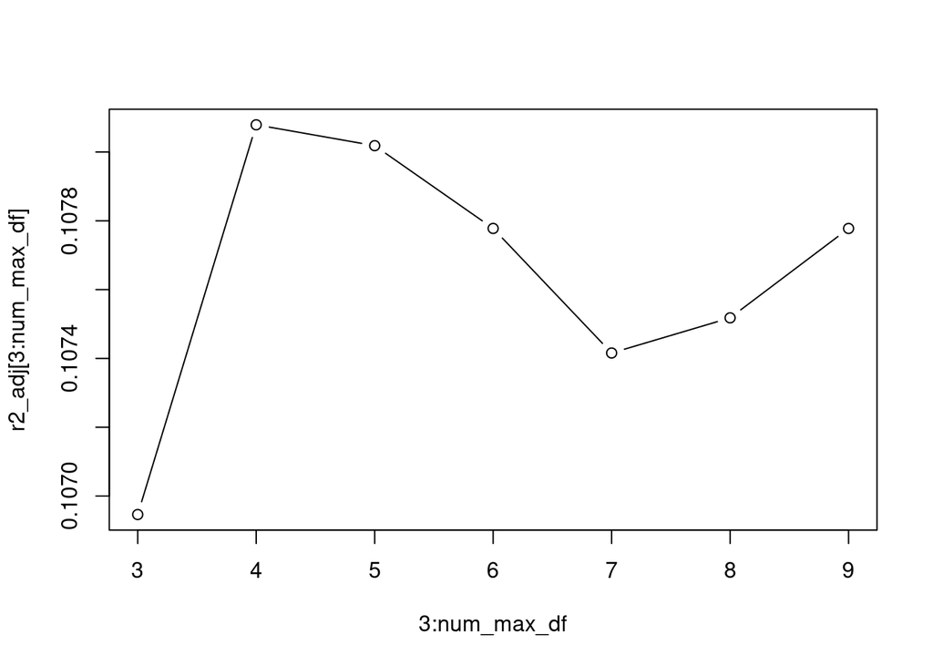

```r
# numero maximo de funciones base => numero maximo de nodos = nmu. max. fb - 3
num_max_df = 9

r2_adj = rep(0, num_max_df)
# empezamos en 3 porque cero nodos son 3 df, un polinomio cubico
for (i in 3:num_max_df){
  m = lm(wage ~ bs(age, df = i), data = d)
  m_summary = summary(m)
  r2_adj[i] = m_summary$adj.r.squared
}

plot(3:num_max_df, r2_adj[3:num_max_df], type = "b")
```

Luego colocar un nodo en el centro parece lo más adecuado.